# Package gssquery

```r
library(gssquery)
```

1. What the package does?

This package can be used to perform fixed effect model where the treatment status is an indicator with two levels, and outcome variable is numeric. Further analyses can be also performed to check the robustness of the main effect. Specifically, event study is included to check if there is a lag or lead of the main effect. In addition, falsification exercises (1) leave one out is included to test the sensitivity of the main effect to subset of sample; (2) random treatment status reshuffling is included to test the sensitivity of the main effect to treatment status reshuffling.

Non-quantitative function such as get attributes, query attributes, plot attribute of a given data is also included.

Deviation: The proposed design of this package is for GSS specifically. The final package can be used for any data with similar structure.

2. Use cases.

Gerneral Social Survey (GSS) data from `gss.norc.org` is included in this package to test its applicability. The raw data is pre-processed as in “/data-raw/GSS.R” to fit the package use, as the raw data is annually, not panel.

The package can be used to test if US presidential election affects household happiness. The corresponding data for this case is included in `GSS.rda`.

2.1. The data `GSS` contains hundreds of attributes. Function `GerAttributes` can be used to show attribute names, so that the user can decide which attribute is useful.

```r
data(GSS)
GetAttributes(data = GSS)
```

```
#>   [1] "abany"         "abdefect"      "abhlth"        "abnomore"
#>   [5] "abpoor"        "abrape"        "absingle"      "acqntsex"
#>   [9] "adults"        "affrmact"      "age"           "aged"
#>  [13] "agekdbrn"      "attend"        "babies"        "bible"
#>  [17] "born"          "cappun"        "childs"        "chldidel"
#>  [21] "class"         "cohort"        "colath"        "colcom"
#>  [25] "colhomo"       "colmil"        "colrac"        "comprend"
#>  [29] "conarmy"       "conbus"        "conclerg"      "condom"
#>  [33] "coneduc"       "confed"        "confinan"      "coninc"
#>  [37] "conjudge"      "conlabor"      "conlegis"      "conmedic"
#>  [41] "conpress"      "conrinc"       "consci"        "contv"
#>  [45] "coop"          "courts"        "crack30"       "dateintv"
#>  [49] "degree"        "denom"         "denom16"       "discaff"
#>  [53] "discaffm"      "discaffw"      "divlaw"        "divorce"
#>  [57] "dwelling"      "dwelown"       "earnrs"        "educ"
```

[output cut: 86 more lines]

For the above effect, related variables are outcome variable `happy.score`, treatment variable `election` which takes value for election years and 0 otherwise, and `re.election` which takes value 2 for re-election years，1 for other election years and 0 otherwise, time fixed effect `year`, and household characteristics affecting election, such as `age`, `income`, `health`, `educ`.

2.2. The function QueryAttributes can be used to query any attribute of interest.

```r
query<-QueryAttributes(data = GSS,'happy','health','income')
head(query)
```

```
#>          happy    health         income
#> 1 pretty happy excellent             .a
#> 2 pretty happy      fair  $8000 to 9999
#> 3 pretty happy      good $15000 - 19999
#> 4   very happy       IAP $25000 or more
#> 5 pretty happy       IAP $25000 or more
#> 6 pretty happy      good             .a
```

2.3. The function `GetCleanLmData` can be used to get attributes of interest, which is cleaned by replacing any value with nonsense by NA. Since `GSS` is a survey data, this is a common issue. The data has to be cleaned before running any quantitative analyses.

```r
LmData <- GetCleanLmData(data = GSS, y = 'happy.score', x = 'election', FE = 'year', common.na.strings = c("DK", "IAP", "UNCODEABLE & IAP", ".a", ".b","DK NA"), 'age', 'income', 'health', 'educ')
head(LmData)
```

```
#>   happy.score election year age         income    health educ
#> 1           2        1 2000  26           <NA> excellent   16
#> 2           2        1 2000  48  $8000 to 9999      fair   15
#> 3           2        1 2000  67 $15000 - 19999      good   13
#> 4           3        1 2000  39 $25000 or more      <NA>   14
#> 5           2        1 2000  25 $25000 or more      <NA>   14
#> 6           2        1 2000  25           <NA>      good   12
```

```r
LmData.reelec <- GetCleanLmData(data = GSS[GSS$re.election != 1,], y = 'happy.score', x = 're.election', FE = 'year', common.na.strings = c("DK", "IAP", "UNCODEABLE & IAP", ".a", ".b","DK NA"), 'age', 'income', 'health', 'educ')
head(LmData.reelec)
```

```
#>      happy.score re.election year age         income    health educ
#> 2818           2           0 2002  25 $25000 or more excellent   14
#> 2819           2           0 2002  43 $25000 or more      good   16
#> 2820           0           0 2002  30 $25000 or more      good   13
#> 2821           0           0 2002  55 $25000 or more      <NA>    2
#> 2822           0           0 2002  37 $25000 or more      good    7
#> 2823           2           0 2002  47 $25000 or more excellent   12
```

```r
LmData.elec <- GetCleanLmData(data = GSS[GSS$re.election != 2,], y = 'happy.score', x = 're.election', FE = 'year', common.na.strings = c("DK", "IAP", "UNCODEABLE & IAP", ".a", ".b","DK NA"), 'age', 'income', 'health', 'educ')
head(LmData.elec)
```

```
#>   happy.score re.election year age         income    health educ
#> 1           2           1 2000  26           <NA> excellent   16
#> 2           2           1 2000  48  $8000 to 9999      fair   15
#> 3           2           1 2000  67 $15000 - 19999      good   13
#> 4           3           1 2000  39 $25000 or more      <NA>   14
#> 5           2           1 2000  25 $25000 or more      <NA>   14
#> 6           2           1 2000  25           <NA>      good   12
```

2.4. The data returned from `GetCleanLmData` can be used for quantitative analyses.

2.4.1. The function `Analysis.lm` can be used to perform fixed effect model, with selected fixed effect, and other control variables.

```r
library(dplyr)
LmData <- LmData %>% mutate(age = as.numeric(age)) %>% filter(age<=60)
summary(Analysis.lm(data = LmData, y = 'happy.score', FE = 'year'))
```

```
#>
#> Call:
#> lm(formula = y ~ ., data = LmData)
#>
#> Residuals:
#>     Min      1Q  Median      3Q     Max
#> -2.4520 -0.6297 -0.0987  0.7159  2.4956
#>
#> Coefficients: (1 not defined because of singularities)
#>                        Estimate Std. Error t value Pr(>|t|)
#> (Intercept)           2.2533110  0.1823189  12.359  < 2e-16 ***
#> election              0.0773455  0.0318767   2.426  0.01526 *
#> year2002             -1.0512063  0.0330548 -31.802  < 2e-16 ***
#> year2004             -0.7723382  0.0327943 -23.551  < 2e-16 ***
#> year2006             -0.8904924  0.0295883 -30.096  < 2e-16 ***
#> year2008             -0.0853499  0.0329993  -2.586  0.00971 **
#> year2010             -0.0336594  0.0360313  -0.934  0.35023
#> year2012             -0.0359996  0.0331960  -1.084  0.27818
#> year2014              0.0393899  0.0334739   1.177  0.23932
#> year2016             -0.0814043  0.0302902  -2.687  0.00721 **
#> year2018                     NA         NA      NA       NA
#> age                   0.0021822  0.0004829   4.519 6.26e-06 ***
#> income$10000 - 14999 -0.0190008  0.0691339  -0.275  0.78344
#> income$15000 - 19999 -0.0346629  0.0700143  -0.495  0.62055
#> income$20000 - 24999 -0.0179698  0.0688058  -0.261  0.79397
#> income$25000 or more  0.0879022  0.0643337   1.366  0.17185
#> income$3000 to 3999  -0.0528407  0.0984979  -0.536  0.59165
#> income$4000 to 4999  -0.0481102  0.1112011  -0.433  0.66528
#> income$5000 to 5999  -0.0395420  0.0983087  -0.402  0.68753
#> income$6000 to 6999  -0.2263282  0.0969719  -2.334  0.01961 *
#> income$7000 to 7999  -0.0670011  0.0915497  -0.732  0.46427
#> income$8000 to 9999  -0.1183268  0.0803348  -1.473  0.14079
#> incomelt $1000       -0.1953622  0.0856116  -2.282  0.02251 *
#> healthfair           -0.3090061  0.0221790 -13.932  < 2e-16 ***
#> healthgood           -0.1430445  0.0171987  -8.317  < 2e-16 ***
#> healthpoor           -0.4980266  0.0356004 -13.989  < 2e-16 ***
#> educ1                -0.0813804  0.3508007  -0.232  0.81655
#> educ10               -0.0729830  0.1726171  -0.423  0.67245
#> educ11               -0.0776291  0.1709405  -0.454  0.64974
#> educ12               -0.1106903  0.1684764  -0.657  0.51119
```

[output cut: 8 more lines]

```
#> educ20               -0.0555060  0.1726452  -0.322  0.74783
#> educ3                -0.1788995  0.2392562  -0.748  0.45463
#> educ4                -0.1206879  0.2371632  -0.509  0.61084
#> educ5                -0.2120217  0.2261778  -0.937  0.34856
#> educ6                 0.0006223  0.1820104   0.003  0.99727
#> educ7                -0.1476960  0.1957754  -0.754  0.45061
#> educ8                -0.1068856  0.1764261  -0.606  0.54463
#> educ9                -0.1977683  0.1743261  -1.134  0.25661
#> ---
#> Signif. codes:  0 '***' 0.001 '**' 0.01 '*' 0.05 '.' 0.1 ' ' 1
#>
#> Residual standard error: 0.8699 on 14921 degrees of freedom
#>   (10064 observations deleted due to missingness)
#> Multiple R-squared:  0.2326, Adjusted R-squared:  0.2304
#> F-statistic: 102.8 on 44 and 14921 DF,  p-value: < 2.2e-16
```

The results indicate households on average are happier by 0.077 in election years (campaign for brand new presidents or re-election) compared to non-election years.

```r
LmData.reelec <- LmData.reelec %>% mutate(age = as.numeric(age)) %>% filter(age<=60)
summary(Analysis.lm(data = LmData.reelec, y = 'happy.score', FE = 'year'))
```

```
#>
#> Call:
#> lm(formula = y ~ ., data = LmData)
#>
#> Residuals:
#>      Min       1Q   Median       3Q      Max
#> -2.41411 -0.98029 -0.09294  0.76331  2.47305
#>
#> Coefficients: (1 not defined because of singularities)
#>                        Estimate Std. Error t value Pr(>|t|)
#> (Intercept)           1.1955321  0.2260621   5.289 1.26e-07 ***
#> re.election           0.5460338  0.0189764  28.774  < 2e-16 ***
#> year2004             -0.7331226  0.0408473 -17.948  < 2e-16 ***
#> year2006              0.1612281  0.0302352   5.332 9.89e-08 ***
#> year2010              1.0134534  0.0379128  26.731  < 2e-16 ***
#> year2012                     NA         NA      NA       NA
#> year2014              1.0903530  0.0349720  31.178  < 2e-16 ***
#> year2018              1.0496928  0.0365437  28.724  < 2e-16 ***
#> age                   0.0018886  0.0006359   2.970  0.00298 **
#> income$10000 - 14999  0.0444625  0.0947356   0.469  0.63884
#> income$15000 - 19999  0.0210126  0.0962254   0.218  0.82715
#> income$20000 - 24999  0.0321004  0.0945003   0.340  0.73410
#> income$25000 or more  0.0989180  0.0886692   1.116  0.26463
#> income$3000 to 3999  -0.0038693  0.1356762  -0.029  0.97725
#> income$4000 to 4999   0.0758529  0.1474535   0.514  0.60697
#> income$5000 to 5999   0.0011038  0.1344927   0.008  0.99345
#> income$6000 to 6999  -0.2330088  0.1311299  -1.777  0.07561 .
#> income$7000 to 7999   0.0568123  0.1260016   0.451  0.65208
#> income$8000 to 9999  -0.0378577  0.1101819  -0.344  0.73116
#> incomelt $1000       -0.1650667  0.1138329  -1.450  0.14707
#> healthfair           -0.2579969  0.0291470  -8.852  < 2e-16 ***
#> healthgood           -0.1165463  0.0226382  -5.148 2.68e-07 ***
#> healthpoor           -0.4482350  0.0468587  -9.566  < 2e-16 ***
#> educ1                -0.3226045  0.4433619  -0.728  0.46685
#> educ10               -0.1204718  0.2120778  -0.568  0.57001
#> educ11               -0.0743970  0.2096558  -0.355  0.72271
#> educ12               -0.1487688  0.2062696  -0.721  0.47078
#> educ13               -0.1046102  0.2077911  -0.503  0.61467
#> educ14               -0.1224630  0.2071954  -0.591  0.55450
#> educ15               -0.1064684  0.2096499  -0.508  0.61158
#> educ16               -0.0592809  0.2071326  -0.286  0.77473
#> educ17               -0.0311322  0.2113192  -0.147  0.88288
#> educ18               -0.0420867  0.2102254  -0.200  0.84133
#> educ19               -0.1238296  0.2167333  -0.571  0.56778
#> educ2                -0.0957552  0.2618281  -0.366  0.71458
#> educ20               -0.0543285  0.2120759  -0.256  0.79782
#> educ3                -0.2676100  0.2899591  -0.923  0.35607
#> educ4                -0.1305060  0.3014420  -0.433  0.66507
#> educ5                -0.1870176  0.2790858  -0.670  0.50280
#> educ6                -0.1233360  0.2259537  -0.546  0.58518
#> educ7                -0.1949802  0.2453240  -0.795  0.42676
#> educ8                -0.1440515  0.2187073  -0.659  0.51014
#> educ9                -0.2480227  0.2149480  -1.154  0.24858
#> ---
#> Signif. codes:  0 '***' 0.001 '**' 0.01 '*' 0.05 '.' 0.1 ' ' 1
#>
#> Residual standard error: 0.9604 on 10425 degrees of freedom
#>   (7379 observations deleted due to missingness)
#> Multiple R-squared:  0.202,  Adjusted R-squared:  0.1988
#> F-statistic: 64.35 on 41 and 10425 DF,  p-value: < 2.2e-16
```

The results indicate households on average are happier by 0.55 in re-election years compared to non-election years.

```r
LmData.elec <- LmData.elec %>% mutate(age = as.numeric(age)) %>% filter(age<=60)
summary(Analysis.lm(data = LmData.elec, y = 'happy.score', FE = 'year'))
```

```
#>
#> Call:
#> lm(formula = y ~ ., data = LmData)
#>
#> Residuals:
#>      Min       1Q   Median       3Q      Max
#> -2.09653 -0.66085 -0.09851  0.71499  2.48016
#>
#> Coefficients: (1 not defined because of singularities)
#>                        Estimate Std. Error t value Pr(>|t|)
#> (Intercept)           2.1724213  0.1877687  11.570  < 2e-16 ***
#> re.election           0.0774637  0.0314069   2.466  0.01366 *
#> year2002             -1.0515520  0.0325574 -32.298  < 2e-16 ***
#> year2006             -0.8909657  0.0291388 -30.577  < 2e-16 ***
#> year2008             -0.0855101  0.0325033  -2.631  0.00853 **
#> year2010             -0.0332370  0.0354752  -0.937  0.34882
#> year2014              0.0388950  0.0329567   1.180  0.23795
#> year2016             -0.0824948  0.0298484  -2.764  0.00572 **
#> year2018                     NA         NA      NA       NA
#> age                   0.0025123  0.0005138   4.890 1.02e-06 ***
#> income$10000 - 14999 -0.0426031  0.0740400  -0.575  0.56503
#> income$15000 - 19999 -0.0413678  0.0749714  -0.552  0.58111
#> income$20000 - 24999 -0.0439594  0.0737494  -0.596  0.55114
#> income$25000 or more  0.0758590  0.0690093   1.099  0.27168
#> income$3000 to 3999  -0.0273683  0.1049251  -0.261  0.79422
#> income$4000 to 4999  -0.0605592  0.1176006  -0.515  0.60659
#> income$5000 to 5999  -0.0614067  0.1036811  -0.592  0.55368
#> income$6000 to 6999  -0.2678122  0.1064060  -2.517  0.01185 *
#> income$7000 to 7999  -0.0806687  0.0988727  -0.816  0.41458
#> income$8000 to 9999  -0.1296681  0.0853756  -1.519  0.12884
#> incomelt $1000       -0.2164908  0.0923529  -2.344  0.01908 *
#> healthfair           -0.3265824  0.0236612 -13.802  < 2e-16 ***
#> healthgood           -0.1567056  0.0184414  -8.497  < 2e-16 ***
#> healthpoor           -0.4967023  0.0376340 -13.198  < 2e-16 ***
#> educ1                 0.3458054  0.4199858   0.823  0.41031
#> educ10                0.0149908  0.1769530   0.085  0.93249
#> educ11                0.0055495  0.1752799   0.032  0.97474
#> educ12               -0.0209602  0.1725212  -0.121  0.90330
#> educ13                0.0149675  0.1737203   0.086  0.93134
#> educ14                0.0166663  0.1732494   0.096  0.92336
#> educ15                0.0625898  0.1753410   0.357  0.72113
#> educ16                0.0727400  0.1732025   0.420  0.67451
#> educ17                0.0991863  0.1768755   0.561  0.57496
#> educ18                0.0802040  0.1754571   0.457  0.64760
#> educ19               -0.0196792  0.1810245  -0.109  0.91343
#> educ2                 0.0554116  0.2221200   0.249  0.80300
#> educ20                0.0203763  0.1773345   0.115  0.90852
#> educ3                -0.1350917  0.2449619  -0.551  0.58131
#> educ4                -0.0343880  0.2508058  -0.137  0.89095
#> educ5                -0.1122938  0.2324666  -0.483  0.62907
#> educ6                 0.1346125  0.1874997   0.718  0.47281
#> educ7                -0.0534215  0.2031390  -0.263  0.79257
#> educ8                -0.0059110  0.1808713  -0.033  0.97393
#> educ9                -0.0880888  0.1787705  -0.493  0.62220
#> ---
#> Signif. codes:  0 '***' 0.001 '**' 0.01 '*' 0.05 '.' 0.1 ' ' 1
#>
#> Residual standard error: 0.8563 on 12701 degrees of freedom
#>   (7778 observations deleted due to missingness)
#> Multiple R-squared:  0.2501, Adjusted R-squared:  0.2476
#> F-statistic: 100.8 on 42 and 12701 DF,  p-value: < 2.2e-16
```

The results indicate households on average are happier by 0.077 in elections years (campaign for brand new presidents) compared to non-election years.

2.4.2. The function `LagEffect` can be used to check if there is a lag effect.

```r
LagEffect(data = LmData, y = 'happy.score', x = 'election', time = 'year', FE = 'year')
```

```
#>
#> Call:
#> lm(formula = y ~ ., data = LmData.pre2)
#>
#> Residuals:
#>      Min       1Q   Median       3Q      Max
#> -2.43487 -0.83180 -0.09316  0.73899  2.49750
#>
#> Coefficients: (1 not defined because of singularities)
#>                        Estimate Std. Error t value Pr(>|t|)
#> (Intercept)           2.2028440  0.1941181  11.348  < 2e-16 ***
#> x.pre2               -1.0461772  0.0328070 -31.889  < 2e-16 ***
#> year2004             -0.6893603  0.0357792 -19.267  < 2e-16 ***
#> year2006              0.1604030  0.0284567   5.637 1.77e-08 ***
#> year2008             -0.0035727  0.0358862  -0.100 0.920697
#> year2010              1.0160094  0.0356766  28.478  < 2e-16 ***
#> year2012              0.0457831  0.0360508   1.270 0.204122
#> year2014              1.0904081  0.0329005  33.143  < 2e-16 ***
#> year2016                     NA         NA      NA       NA
#> year2018              1.0505071  0.0343808  30.555  < 2e-16 ***
#> age                   0.0019360  0.0005338   3.627 0.000288 ***
#> income$10000 - 14999 -0.0121327  0.0766439  -0.158 0.874223
#> income$15000 - 19999 -0.0339724  0.0779158  -0.436 0.662834
#> income$20000 - 24999 -0.0101180  0.0762615  -0.133 0.894452
#> income$25000 or more  0.0823391  0.0711182   1.158 0.246976
#> income$3000 to 3999  -0.0717156  0.1102272  -0.651 0.515306
#> income$4000 to 4999  -0.0085030  0.1232242  -0.069 0.944987
#> income$5000 to 5999  -0.0609246  0.1104130  -0.552 0.581103
#> income$6000 to 6999  -0.2407547  0.1081052  -2.227 0.025962 *
#> income$7000 to 7999  -0.0114012  0.1025293  -0.111 0.911460
#> income$8000 to 9999  -0.0904882  0.0901431  -1.004 0.315480
#> incomelt $1000       -0.2182395  0.0938898  -2.324 0.020118 *
#> healthfair           -0.2881541  0.0245135 -11.755  < 2e-16 ***
#> healthgood           -0.1278674  0.0192438  -6.645 3.16e-11 ***
#> healthpoor           -0.4762711  0.0391515 -12.165  < 2e-16 ***
#> educ1                -0.0456089  0.3663824  -0.124 0.900934
#> educ10               -0.0516756  0.1835407  -0.282 0.778294
#> educ11               -0.0227897  0.1814949  -0.126 0.900077
#> educ12               -0.0691664  0.1786426  -0.387 0.698631
#> educ13               -0.0234941  0.1799394  -0.131 0.896120
#> educ14               -0.0473120  0.1794057  -0.264 0.792003
#> educ15               -0.0220382  0.1815244  -0.121 0.903371
#> educ16                0.0148492  0.1793576   0.083 0.934019
#> educ17                0.0338406  0.1829096   0.185 0.853222
#> educ18                0.0307244  0.1817472   0.169 0.865760
#> educ19               -0.0414656  0.1870553  -0.222 0.824570
#> educ2                 0.0157641  0.2294070   0.069 0.945216
#> educ20               -0.0024276  0.1833564  -0.013 0.989437
#> educ3                -0.1243677  0.2563028  -0.485 0.627516
#> educ4                -0.0829545  0.2513236  -0.330 0.741352
#> educ5                -0.1520580  0.2449406  -0.621 0.534745
#> educ6                 0.0354196  0.1934758   0.183 0.854746
#> educ7                -0.0992953  0.2101620  -0.472 0.636599
#> educ8                -0.0506500  0.1888784  -0.268 0.788579
#> educ9                -0.1578998  0.1855141  -0.851 0.394703
#> ---
#> Signif. codes:  0 '***' 0.001 '**' 0.01 '*' 0.05 '.' 0.1 ' ' 1
#>
#> Residual standard error: 0.9044 on 13034 degrees of freedom
#>   (11952 observations deleted due to missingness)
#> Multiple R-squared:  0.219,  Adjusted R-squared:  0.2164
#> F-statistic:    85 on 43 and 13034 DF,  p-value: < 2.2e-16
```

The results indicate the election (for brand new presidents or re-election) causes households to be less happy by 1.04 two years later.

```r
LagEffect(data = LmData.elec, y = 'happy.score', x = 're.election', time = 'year', FE = 'year')
```

```
#>
#> Call:
#> lm(formula = y ~ ., data = LmData.pre2)
#>
#> Residuals:
#>     Min      1Q  Median      3Q     Max
#> -2.0231 -0.4483 -0.1034  0.7081  2.4314
#>
#> Coefficients: (1 not defined because of singularities)
#>                        Estimate Std. Error t value Pr(>|t|)
#> (Intercept)           2.1354454  0.2587483   8.253  < 2e-16 ***
#> x.pre2               -1.0438917  0.0291506 -35.810  < 2e-16 ***
#> year2008             -0.0011193  0.0318034  -0.035   0.9719
#> year2010              1.0191012  0.0316285  32.221  < 2e-16 ***
#> year2016                     NA         NA      NA       NA
#> year2018              1.0505395  0.0305201  34.421  < 2e-16 ***
#> age                   0.0030142  0.0006539   4.610 4.11e-06 ***
#> income$10000 - 14999 -0.0777752  0.0915773  -0.849   0.3958
#> income$15000 - 19999 -0.0699015  0.0932625  -0.750   0.4536
#> income$20000 - 24999 -0.0073877  0.0909914  -0.081   0.9353
#> income$25000 or more  0.0880561  0.0843634   1.044   0.2966
#> income$3000 to 3999  -0.0450122  0.1275903  -0.353   0.7243
#> income$4000 to 4999  -0.1754238  0.1573448  -1.115   0.2649
#> income$5000 to 5999  -0.1228287  0.1316556  -0.933   0.3509
#> income$6000 to 6999  -0.2512418  0.1386169  -1.812   0.0700 .
#> income$7000 to 7999  -0.1110234  0.1266276  -0.877   0.3806
#> income$8000 to 9999  -0.1373601  0.1071237  -1.282   0.1998
#> incomelt $1000       -0.2681943  0.1126831  -2.380   0.0173 *
#> healthfair           -0.3283274  0.0305189 -10.758  < 2e-16 ***
#> healthgood           -0.1469719  0.0245414  -5.989 2.23e-09 ***
#> healthpoor           -0.4967174  0.0485442 -10.232  < 2e-16 ***
#> educ1                 0.6574486  0.5214861   1.261   0.2075
#> educ10               -0.0014824  0.2488932  -0.006   0.9952
#> educ11                0.0499716  0.2465608   0.203   0.8394
#> educ12                0.0088898  0.2430500   0.037   0.9708
#> educ13                0.0165142  0.2446476   0.068   0.9462
#> educ14               -0.0177548  0.2439878  -0.073   0.9420
#> educ15                0.0184624  0.2462773   0.075   0.9402
#> educ16                0.0552727  0.2439363   0.227   0.8208
#> educ17                0.1159361  0.2484548   0.467   0.6408
#> educ18                0.0651813  0.2463673   0.265   0.7913
#> educ19                0.0984400  0.2528745   0.389   0.6971
#> educ2                 0.2454142  0.3142605   0.781   0.4349
#> educ20                0.0093252  0.2486011   0.038   0.9701
#> educ3                 0.1730978  0.3339986   0.518   0.6043
#> educ4                -0.1755438  0.3283691  -0.535   0.5929
#> educ5                 0.0882726  0.3610140   0.245   0.8068
#> educ6                 0.1714677  0.2620246   0.654   0.5129
#> educ7                -0.0976631  0.2803095  -0.348   0.7275
#> educ8                 0.1838053  0.2541527   0.723   0.4696
#> educ9                -0.0662097  0.2506766  -0.264   0.7917
#> ---
#> Signif. codes:  0 '***' 0.001 '**' 0.01 '*' 0.05 '.' 0.1 ' ' 1
#>
#> Residual standard error: 0.7993 on 6495 degrees of freedom
#>   (13987 observations deleted due to missingness)
#> Multiple R-squared:  0.2647, Adjusted R-squared:  0.2602
#> F-statistic: 59.94 on 39 and 6495 DF,  p-value: < 2.2e-16
```

The results indicate the election (for brand new presidents) causes households to be less happy by 1.04 two years later.

```r
LagEffect(data = LmData.reelec, y = 'happy.score', x = 're.election', time = 'year', FE = 'year')
```

```
#>
#> Call:
#> lm(formula = y ~ ., data = LmData.pre2)
#>
#> Residuals:
#>      Min       1Q   Median       3Q      Max
#> -2.40105 -1.05567 -0.08598  0.74660  2.19232
#>
#> Coefficients: (1 not defined because of singularities)
#>                        Estimate Std. Error t value Pr(>|t|)
#> (Intercept)           1.5417530  0.2873771   5.365 8.38e-08 ***
#> x.pre2                0.3682509  0.0198578  18.544  < 2e-16 ***
#> year2006             -0.9317878  0.0322226 -28.917  < 2e-16 ***
#> year2012              0.7364186  0.0425027  17.326  < 2e-16 ***
#> year2014                     NA         NA      NA       NA
#> age                   0.0006358  0.0008537   0.745 0.456397
#> income$10000 - 14999  0.0685416  0.1260973   0.544 0.586762
#> income$15000 - 19999  0.0212287  0.1279894   0.166 0.868270
#> income$20000 - 24999 -0.0078423  0.1256073  -0.062 0.950218
#> income$25000 or more  0.0889770  0.1178635   0.755 0.450327
#> income$3000 to 3999  -0.1307548  0.1895493  -0.690 0.490332
#> income$4000 to 4999   0.1469183  0.1908838   0.770 0.441521
#> income$5000 to 5999   0.0041036  0.1822888   0.023 0.982040
#> income$6000 to 6999  -0.2280373  0.1674052  -1.362 0.173186
#> income$7000 to 7999   0.1010046  0.1634168   0.618 0.536544
#> income$8000 to 9999  -0.0178826  0.1490691  -0.120 0.904517
#> incomelt $1000       -0.1704196  0.1536081  -1.109 0.267280
#> healthfair           -0.2434532  0.0386184  -6.304 3.09e-10 ***
#> healthgood           -0.1108195  0.0295009  -3.756 0.000174 ***
#> healthpoor           -0.4513433  0.0619489  -7.286 3.58e-13 ***
#> educ1                -0.4910074  0.5170557  -0.950 0.342340
#> educ10               -0.0744075  0.2677518  -0.278 0.781100
#> educ11               -0.0654474  0.2644646  -0.247 0.804551
#> educ12               -0.1169413  0.2597932  -0.450 0.652630
#> educ13               -0.0352362  0.2619116  -0.135 0.892984
#> educ14               -0.0457190  0.2610571  -0.175 0.860983
#> educ15               -0.0264945  0.2647808  -0.100 0.920298
#> educ16                0.0046501  0.2609288   0.018 0.985782
#> educ17               -0.0117141  0.2663821  -0.044 0.964926
#> educ18                0.0279341  0.2654294   0.105 0.916188
#> educ19               -0.1438695  0.2737467  -0.526 0.599214
#> educ2                -0.1261797  0.3319449  -0.380 0.703867
#> educ20                0.0185424  0.2675208   0.069 0.944744
#> educ3                -0.3917933  0.3872218  -1.012 0.311668
#> educ4                 0.0754871  0.3796731   0.199 0.842409
#> educ5                -0.2545171  0.3420917  -0.744 0.456902
#> educ6                -0.0694629  0.2825292  -0.246 0.805798
#> educ7                -0.0781087  0.3113996  -0.251 0.801953
#> educ8                -0.2798626  0.2780782  -1.006 0.314252
#> educ9                -0.2174588  0.2718243  -0.800 0.423741
#> ---
#> Signif. codes:  0 '***' 0.001 '**' 0.01 '*' 0.05 '.' 0.1 ' ' 1
#>
#> Residual standard error: 0.9979 on 6504 degrees of freedom
#>   (11303 observations deleted due to missingness)
#> Multiple R-squared:  0.175,  Adjusted R-squared:  0.1701
#> F-statistic: 36.29 on 38 and 6504 DF,  p-value: < 2.2e-16
```

The results indicate the re-election causes households to be happier by 0.37 two years later.

2.4.3. The function `LeadEffect` can be used to check if there is lead effect.

```r
LeadEffect(data = LmData, y = 'happy.score', x = 'election', time = 'year', FE = 'year')
```

```
#>
#> Call:
#> lm(formula = y ~ ., data = LmData.post2)
#>
#> Residuals:
#>     Min      1Q  Median      3Q     Max
#> -2.4465 -0.7302 -0.1005  0.7212  2.4823
#>
#> Coefficients: (1 not defined because of singularities)
#>                        Estimate Std. Error t value Pr(>|t|)
#> (Intercept)           2.4095752  0.1929636  12.487  < 2e-16 ***
#> x.post2              -0.0387249  0.0310460  -1.247  0.21229
#> year2002             -1.0900481  0.0323111 -33.736  < 2e-16 ***
#> year2004             -0.7724639  0.0334956 -23.062  < 2e-16 ***
#> year2006             -0.9294423  0.0285911 -32.508  < 2e-16 ***
#> year2008             -0.0858535  0.0337083  -2.547  0.01088 *
#> year2010             -0.0732240  0.0354782  -2.064  0.03904 *
#> year2012             -0.0366572  0.0339084  -1.081  0.27969
#> year2014                     NA         NA      NA       NA
#> year2016             -0.0824366  0.0309488  -2.664  0.00774 **
#> age                   0.0022091  0.0005201   4.247 2.18e-05 ***
#> income$10000 - 14999 -0.0528250  0.0736042  -0.718  0.47296
#> income$15000 - 19999 -0.0642108  0.0744348  -0.863  0.38835
#> income$20000 - 24999 -0.0617986  0.0732117  -0.844  0.39862
#> income$25000 or more  0.0506939  0.0684777   0.740  0.45913
#> income$3000 to 3999  -0.1235076  0.1054268  -1.172  0.24142
#> income$4000 to 4999  -0.0861328  0.1187742  -0.725  0.46835
#> income$5000 to 5999  -0.0689996  0.1045147  -0.660  0.50914
#> income$6000 to 6999  -0.2552126  0.1018601  -2.506  0.01224 *
#> income$7000 to 7999  -0.1005681  0.0964105  -1.043  0.29691
#> income$8000 to 9999  -0.1424263  0.0856515  -1.663  0.09636 .
#> incomelt $1000       -0.2181058  0.0919245  -2.373  0.01767 *
#> healthfair           -0.3032055  0.0237134 -12.786  < 2e-16 ***
#> healthgood           -0.1331041  0.0182454  -7.295 3.15e-13 ***
#> healthpoor           -0.4804936  0.0381324 -12.601  < 2e-16 ***
#> educ1                -0.2475771  0.3806358  -0.650  0.51543
#> educ10               -0.1164906  0.1833094  -0.635  0.52512
#> educ11               -0.1307145  0.1814992  -0.720  0.47142
#> educ12               -0.1640191  0.1788680  -0.917  0.35917
#> educ13               -0.1213095  0.1800353  -0.674  0.50044
#> educ14               -0.1319428  0.1795906  -0.735  0.46254
#> educ15               -0.0870111  0.1815787  -0.479  0.63181
#> educ16               -0.0787137  0.1795483  -0.438  0.66110
#> educ17               -0.0605356  0.1828131  -0.331  0.74055
#> educ18               -0.0665372  0.1817540  -0.366  0.71431
#> educ19               -0.1370066  0.1869812  -0.733  0.46374
#> educ2                -0.0812121  0.2292096  -0.354  0.72311
#> educ20               -0.1022217  0.1833237  -0.558  0.57713
#> educ3                -0.3944725  0.2668561  -1.478  0.13937
#> educ4                -0.1779261  0.2517804  -0.707  0.47978
#> educ5                -0.2304099  0.2376936  -0.969  0.33238
#> educ6                -0.0414030  0.1926639  -0.215  0.82985
#> educ7                -0.1970596  0.2071934  -0.951  0.34158
#> educ8                -0.1683552  0.1872947  -0.899  0.36873
#> educ9                -0.2603626  0.1851812  -1.406  0.15975
#> ---
#> Signif. codes:  0 '***' 0.001 '**' 0.01 '*' 0.05 '.' 0.1 ' ' 1
#>
#> Residual standard error: 0.8883 on 13670 degrees of freedom
#>   (11316 observations deleted due to missingness)
#> Multiple R-squared:  0.2313, Adjusted R-squared:  0.2289
#> F-statistic: 95.65 on 43 and 13670 DF,  p-value: < 2.2e-16
```

The results indicate household happiness in two years before the election has no statistically difference between election (for brand new president or re-election) years and non-election years .

```r
LeadEffect(data = LmData.elec, y = 'happy.score', x = 're.election', time = 'year', FE = 'year')
```

```
#>
#> Call:
#> lm(formula = y ~ ., data = LmData.post2)
#>
#> Residuals:
#>      Min       1Q   Median       3Q      Max
#> -1.97910 -0.46289 -0.09241  0.68655  2.29222
#>
#> Coefficients: (1 not defined because of singularities)
#>                        Estimate Std. Error t value Pr(>|t|)
#> (Intercept)           2.2144389  0.2160827  10.248  < 2e-16 ***
#> x.post2              -0.0371928  0.0293870  -1.266   0.2057
#> year2006             -0.9315999  0.0270263 -34.470  < 2e-16 ***
#> year2008             -0.0862963  0.0318755  -2.707   0.0068 **
#> year2014                     NA         NA      NA       NA
#> year2016             -0.0805673  0.0293138  -2.748   0.0060 **
#> age                   0.0019382  0.0006139   3.157   0.0016 **
#> income$10000 - 14999 -0.0678127  0.0866732  -0.782   0.4340
#> income$15000 - 19999 -0.0733044  0.0875640  -0.837   0.4025
#> income$20000 - 24999 -0.0996343  0.0861959  -1.156   0.2478
#> income$25000 or more  0.0590637  0.0805487   0.733   0.4634
#> income$3000 to 3999  -0.1049253  0.1259320  -0.833   0.4048
#> income$4000 to 4999  -0.0693260  0.1359130  -0.510   0.6100
#> income$5000 to 5999  -0.0751733  0.1218952  -0.617   0.5374
#> income$6000 to 6999  -0.2671659  0.1221452  -2.187   0.0287 *
#> income$7000 to 7999  -0.0951599  0.1137650  -0.836   0.4029
#> income$8000 to 9999  -0.1602684  0.1005417  -1.594   0.1110
#> incomelt $1000       -0.2398965  0.1118277  -2.145   0.0320 *
#> healthfair           -0.3476601  0.0280528 -12.393  < 2e-16 ***
#> healthgood           -0.1691764  0.0216379  -7.819 5.96e-15 ***
#> healthpoor           -0.5203186  0.0443681 -11.727  < 2e-16 ***
#> educ1                 0.3207721  0.4640798   0.691   0.4895
#> educ10                0.1013576  0.2043472   0.496   0.6199
#> educ11                0.0375094  0.2024537   0.185   0.8530
#> educ12                0.0501887  0.1990888   0.252   0.8010
#> educ13                0.1120929  0.2005481   0.559   0.5762
#> educ14                0.1262592  0.1999535   0.631   0.5278
#> educ15                0.1929461  0.2027722   0.952   0.3414
#> educ16                0.1705099  0.1998800   0.853   0.3936
#> educ17                0.1600526  0.2043329   0.783   0.4335
#> educ18                0.1767625  0.2026275   0.872   0.3830
#> educ19               -0.0013135  0.2092293  -0.006   0.9950
#> educ2                 0.0717334  0.2596066   0.276   0.7823
#> educ20                0.1000120  0.2048869   0.488   0.6255
#> educ3                -0.2027004  0.2992209  -0.677   0.4982
#> educ4                 0.1417427  0.2888405   0.491   0.6236
#> educ5                -0.1373374  0.2619349  -0.524   0.6001
#> educ6                 0.2645183  0.2147536   1.232   0.2181
#> educ7                 0.0854086  0.2348590   0.364   0.7161
#> educ8                -0.0208100  0.2089481  -0.100   0.9207
#> educ9                -0.0020872  0.2063560  -0.010   0.9919
#> ---
#> Signif. codes:  0 '***' 0.001 '**' 0.01 '*' 0.05 '.' 0.1 ' ' 1
#>
#> Residual standard error: 0.8382 on 8780 degrees of freedom
#>   (11702 observations deleted due to missingness)
#> Multiple R-squared:  0.2427, Adjusted R-squared:  0.2393
#> F-statistic: 72.14 on 39 and 8780 DF,  p-value: < 2.2e-16
```

The results indicate household happiness in two years before the election has no statistically difference between election (for brand new president) years and non-election years .

```r
LeadEffect(data = LmData.reelec, y = 'happy.score', x = 're.election', time = 'year', FE = 'year')
```

```
#>
#> Call:
#> lm(formula = y ~ ., data = LmData.post2)
#>
#> Residuals:
#>      Min       1Q   Median       3Q      Max
#> -2.35145 -0.97681 -0.08906  0.78787  2.34154
#>
#> Coefficients: (1 not defined because of singularities)
#>                       Estimate Std. Error t value Pr(>|t|)
#> (Intercept)           2.900020   0.391782   7.402 1.57e-13 ***
#> x.post2              -0.546286   0.019241 -28.391  < 2e-16 ***
#> year2004             -0.731027   0.041362 -17.674  < 2e-16 ***
#> year2010              1.011610   0.038463  26.301  < 2e-16 ***
#> year2012                    NA         NA      NA       NA
#> age                   0.002610   0.000949   2.750  0.00598 **
#> income$10000 - 14999 -0.015632   0.134844  -0.116  0.90772
#> income$15000 - 19999 -0.035813   0.136500  -0.262  0.79305
#> income$20000 - 24999  0.026679   0.134308   0.199  0.84255
#> income$25000 or more  0.049647   0.125723   0.395  0.69294
#> income$3000 to 3999  -0.140099   0.188672  -0.743  0.45779
#> income$4000 to 4999  -0.137695   0.232182  -0.593  0.55318
#> income$5000 to 5999  -0.037319   0.194881  -0.191  0.84815
#> income$6000 to 6999  -0.205973   0.181315  -1.136  0.25602
#> income$7000 to 7999  -0.072190   0.176162  -0.410  0.68198
#> income$8000 to 9999  -0.087421   0.157758  -0.554  0.57950
#> incomelt $1000       -0.196405   0.160918  -1.221  0.22232
#> healthfair           -0.225847   0.043123  -5.237 1.70e-07 ***
#> healthgood           -0.069423   0.032979  -2.105  0.03534 *
#> healthpoor           -0.410381   0.071621  -5.730 1.07e-08 ***
#> educ1                -1.279118   0.674159  -1.897  0.05784 .
#> educ10               -0.685384   0.377200  -1.817  0.06927 .
#> educ11               -0.624255   0.373558  -1.671  0.09477 .
#> educ12               -0.735773   0.369338  -1.992  0.04641 *
#> educ13               -0.725294   0.371305  -1.953  0.05083 .
#> educ14               -0.782997   0.370626  -2.113  0.03468 *
#> educ15               -0.760481   0.373130  -2.038  0.04159 *
#> educ16               -0.718269   0.370611  -1.938  0.05267 .
#> educ17               -0.642447   0.375086  -1.713  0.08681 .
#> educ18               -0.691207   0.374103  -1.848  0.06472 .
#> educ19               -0.566512   0.382397  -1.481  0.13855
#> educ2                -0.531856   0.456653  -1.165  0.24420
#> educ20               -0.653009   0.375978  -1.737  0.08248 .
#> educ3                -0.858066   0.540865  -1.586  0.11270
#> educ4                -0.936111   0.491087  -1.906  0.05668 .
#> educ5                -0.385299   0.504528  -0.764  0.44509
#> educ6                -0.820438   0.396800  -2.068  0.03873 *
#> educ7                -0.900745   0.413812  -2.177  0.02955 *
#> educ8                -0.586812   0.384628  -1.526  0.12716
#> educ9                -0.907884   0.381155  -2.382  0.01726 *
#> ---
#> Signif. codes:  0 '***' 0.001 '**' 0.01 '*' 0.05 '.' 0.1 ' ' 1
#>
#> Residual standard error: 0.97 on 4855 degrees of freedom
#>   (12952 observations deleted due to missingness)
#> Multiple R-squared:  0.2017, Adjusted R-squared:  0.1955
#> F-statistic: 32.28 on 38 and 4855 DF,  p-value: < 2.2e-16
```

The results indicate households are less happy by 0.55 two years before re-election.

2.4.4. The function `PlaceboTSReshuffle` can be used to check if the effect from original treatment status is an outlier from random reshuffling of treatment status. If the effect is truely a causal effect, then the coefficient from original treatment status should stand out.

```r
PlaceboTSReshuffle(data = LmData, y = 'happy.score', x = 'election', FE = 'year')
```

[output not shown]

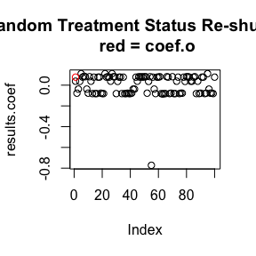

```r
PlaceboTSReshuffle(data = LmData.elec, y = 'happy.score', x = 're.election', FE = 'year')
```

[output not shown]

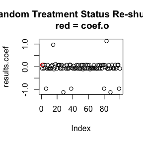

```r
PlaceboTSReshuffle(data = LmData.reelec, y = 'happy.score', x = 're.election', FE = 'year')
```

[output not shown]

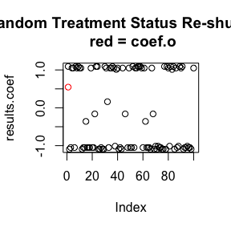

2.4.5. The function `PlaceboLOU` can be used to check if the main effect is sensitive to subset of sample. The argument `out` specifies group variable. For example, `out = "year"`, then the main effect will be re-examined for sub sample where one year is droped.

```r
PlaceboLOU(data = LmData, y = 'happy.score', x = 'election', FE = 'year', out = 'year')
```

```
#>    year       coef          pval
#> 1  2000 1.04617717 6.147898e-215
#> 2  2002 0.07514846  1.297244e-02
#> 3  2004 0.07666103  1.282917e-02
#> 4  2006 0.07601693  7.808257e-03
#> 5  2008 0.07766463  1.682228e-02
#> 6  2010 0.07851208  1.571737e-02
#> 7  2012 0.07807795  1.628276e-02
#> 8  2014 0.07925590  1.551641e-02
#> 9  2016 0.07722203  1.833815e-02
#> 10 2018 0.03872492  2.122937e-01
```

```r
PlaceboLOU(data = LmData.elec, y = 'happy.score', x = 're.election', FE = 'year', out = 'year')
```

```
#>   year       coef          pval
#> 1 2000 1.04530676 2.570806e-216
#> 2 2002 0.07474321  1.080919e-02
#> 3 2006 0.07591735  5.030641e-03
#> 4 2008 0.07787463  1.527869e-02
#> 5 2010 0.07880021  1.415863e-02
#> 6 2014 0.07967980  1.392987e-02
#> 7 2016 0.07749241  1.675161e-02
#> 8 2018 0.03959284  1.969712e-01
```

```r
PlaceboLOU(data = LmData.reelec, y = 'happy.score', x = 're.election', FE = 'year', out = 'year')
```

```
#>   year       coef          pval
#> 1 2002 -0.3483335  1.057807e-74
#> 2 2004  0.5466832 3.918069e-185
#> 3 2006  0.5473324 2.416585e-211
#> 4 2010  0.5458787 9.305536e-164
#> 5 2012  0.1793467  2.557236e-20
#> 6 2014  0.5454458 2.514944e-159
#> 7 2018  0.5456408 2.508461e-162
```

The results indicate that the direction of the effect of US presidential re-election on household happiness is reversed after dropping year 2002. And the effect of US presidential election on household happiness is much larger after dropping year 2000.

2.5. The function `PlotAttribute` can be used to plot a chosen attribute with given group variable. GSS data are almost all categorical with level fewer than 15, so the function does a bar plot by year group. For a small exceptions like `age`, this function plot the mean by group.

This visualization shows the trend (sample distribution) of attribute.

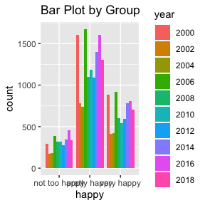

```r
PlotAttribute(data = GSS, attr = "happy", group.by = "year")
```

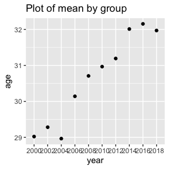

```r
PlotAttribute(data = GSS, attr = "age", group.by = "year")
```